# Cluster Analysis

WDI Indicators

Erfan Hosseini_93101373

2018-06-13 11:26:05

> با توجه به داده بانک جهانی به سوالات زیر پاسخ دهید. برای استفاده از داده از سه فایل زیر استفاده نمایید. داده نام کشورها: WDICountry داده نام سری های زمانی: WDISeries داده کل: WDIData در صورتی که داده را در اختیار ندارید می توانید از بسته WDI استفاده نموده و داده های مورد نظر را استخراج نمایید.

```r
rm(list = ls())
library(dplyr)
library(readr)
library(highcharter)
library(ggplot2)
path = '~/R/HW10/hw_10/data'
wdidata = read_csv(paste(path, 'WDIData.csv', sep = '/'))
```

۱. ده کشور فقیر دنیا را بیابید. نمودار درآمد روزانه آنها را رسم کنید. چند درصد از اعضای این کشورها زیر خط فقر هستند؟ متوسط عمر در این کشورها چقدر است؟

```r
wdidata %>% filter(`Indicator Code` == "NY.GDP.PCAP.CD") -> GDPperCapita
GDPperCapita %>% select(`Country Name`, `2016`) %>% na.omit() %>% arrange(`2016`)  -> GDPperCapita
top10Poor = GDPperCapita %>% select(`Country Name`, GDPperCapita = `2016`) %>% head(10)
hchart(top10Poor, hcaes(x = `Country Name`, y=GDPperCapita/365), type = 'bar') %>%
    hc_yAxis(title = list(text = 'GDP per Capita per Day')) %>%
    hc_title(text= 'Top 10 Poor Countries') %>%
    hc_xAxis(title = list(text = 'Country Name'))
```

[interactive chart not shown]

```r
wdidata %>% filter(`Indicator Code` == "SI.POV.NAHC") -> povertyHeadCount
povHeadCountTop10 = povertyHeadCount %>% filter(`Country Name` %in% top10Poor$`Country Name`)
povHeadCountTop10$overalRatio = rowMeans(povHeadCountTop10 %>% select(5:62), na.rm = T)
povHeadCountTop10 %>% select(`Country Name`, overalRatio) %>% na.omit() -> povHeadCountTop10
hchart(povHeadCountTop10, hcaes(x = `Country Name`, overalRatio), type = 'bar') %>%
    hc_yAxis(title = list(text = 'Poverty Head Count (percentage of total population)')) %>%
    hc_title(text= 'Poverty Head Count for Top 10 Poor Countries') %>%
    hc_xAxis(title = list(text = 'Country Name'))
```

[interactive chart not shown]

```r
wdidata %>% filter(`Indicator Code` == "SP.DYN.LE00.IN") -> lifeExp
lifeExptop10Poor = lifeExp %>% filter(`Country Name` %in% top10Poor$`Country Name`) %>% select(`Country Name`, LifeExpectancy = `2016`)
hchart(lifeExptop10Poor, hcaes(x = `Country Name`, y = LifeExpectancy), type = 'bar') %>%
    hc_yAxis(title = list(text = 'Life Expectancy')) %>%
    hc_title(text= 'Life Expectancy for Top 10 Poor Countries') %>%
    hc_xAxis(title = list(text = 'Country Name'))
```

[interactive chart not shown]

۲. تراژدی روآندا: بر اساس داده های امید به زندگی ابتدا نمودار سالانه نمودار جعبه ایی امید به زندگی کشورها را رسم نمایید(در یک نمودار!). سپس سری زمانی امید به زندگی روآندا را به آن اضافه کنید. چه می بینید؟ چند میلیون نفر کشته شدند؟

In figure below the red dots illustrate Rwnada life expectancy over time! An estimated 500K to 1000K Rwandans were killed during the 100 day period from 7 April to mid-July 1994.

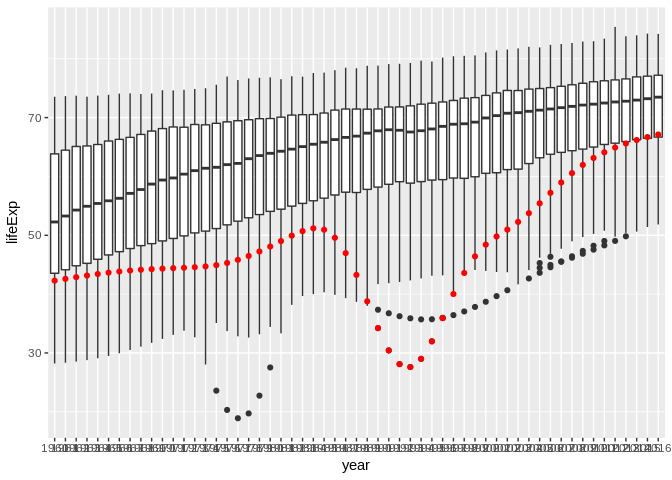

```r
rwaLifeExp = lifeExp %>% filter(`Country Name` == 'Rwanda')
alt = data.frame()
for(i in 0:56){
    tmp = lifeExp %>% select(5+i, `Country Name`) %>% mutate(year = 1960+i) %>% select(lifeExp = 1, year, `Country Name`)
    alt = bind_rows(alt, tmp)
}
alt$year = as.factor(alt$year)
ggplot(data = alt, aes(year, lifeExp)) + geom_boxplot() + geom_point(data = alt %>% filter(`Country Name` == 'Rwanda'), color = 'red')
```

۳. نمودار امید به زندگی و هزینه های بهداشتی را رسم کنید. چه نتیجه ایی می گیرید؟

As we can see from the plot and result of corelation test, corelation between health expenditure and life expectancy is very small.

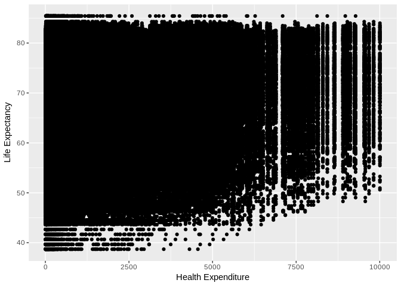

```r
wdidata %>% filter(`Indicator Code` == 'SH.XPD.CHEX.PC.CD') -> healthExpenditure
res = data.frame()
for(i in 0:56){
    tmp = lifeExp %>% select(5+i) %>% mutate(year = 1960+i) %>% select(lifeExp = 1, year)
    tmp1 = healthExpenditure %>% select(5+i) %>% mutate(year = 1960+i) %>% select(healthExp = 1, year)
    tmp = full_join(tmp, tmp1)
    res = bind_rows(res, tmp)
}
res = res %>% na.omit()
ggplot(data = res, aes(y = lifeExp, x= healthExp)) + geom_point() + xlab('Health Expenditure') + ylab('Life Expectancy')
```

```r
cor.test(res$lifeExp, res$healthExp)
```

```
##
##  Pearson's product-moment correlation
##
## data:  res$lifeExp and res$healthExp
## t = 25.245, df = 916100, p-value < 2.2e-16
## alternative hypothesis: true correlation is not equal to 0
## 95 percent confidence interval:
##  0.02432021 0.02841285
## sample estimates:
##        cor
## 0.02636664
```

۴. آیا قدرت خرید خانواده های ایرانی در ۵۰ سال اخیر افزایش یافته است؟ برای این کار از داده های اقتصادی خانوار استفاده کنید.

As we can see from the plot below household purchasing power has an upward trend.

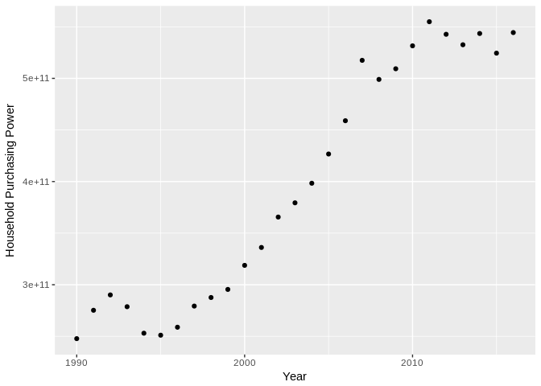

```r
wdidata %>% filter(`Indicator Code` == 'NE.CON.PRVT.PP.KD') -> purchasingPower
purchasingPower %>% filter(`Country Code` == 'IRN') -> iranPurchPow
alt = data.frame()
for(i in 0:56){
    tmp = iranPurchPow %>% select(5+i, `Country Name`) %>% mutate(year = 1960+i) %>% select(purchasingPower = 1, year, `Country Name`)
    alt = bind_rows(alt, tmp)
}
alt = alt %>% na.omit()
ggplot(data=alt, aes(x = year, y = purchasingPower)) + geom_point() + xlab('Year') +
    ylab('Household Purchasing Power')
```

۵. رشد اقتصادی ایران را با کشورهای دیگر در طول ۲۰ سال گذشته بر حسب بیست شاخص های اقتصادی مهم مانند تولید ناخالص ملی، تورم و … ارزیابی کنید! (برای هر شاخص از تصویرسازی استفاده کنید.)

For each economical factor boxplot of all countries vs year accompanied by Iran’s time serie is depicted.

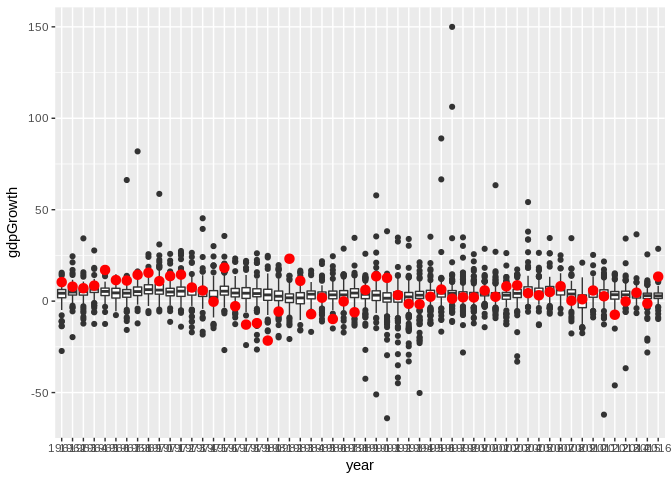

```r
# GPD growth rate
wdidata %>% filter(`Indicator Code` == 'NY.GDP.MKTP.KD.ZG') -> gdpGrow
alt = data.frame()
for(i in 0:56){
    tmp = gdpGrow %>% select(5+i, `Country Code`) %>% mutate(year = 1960+i) %>% select(gdpGrowth = 1, year, `Country Code`)
    alt = bind_rows(alt, tmp)
}
gdpGrow = alt %>% na.omit()
gdpGrow$year = as.factor(gdpGrow$year)
ggplot(data = gdpGrow, aes(x = year, y = gdpGrowth)) + geom_boxplot() +
    geom_point(data = gdpGrow %>% filter(`Country Code` == 'IRN'), color='red', size = 3)
```

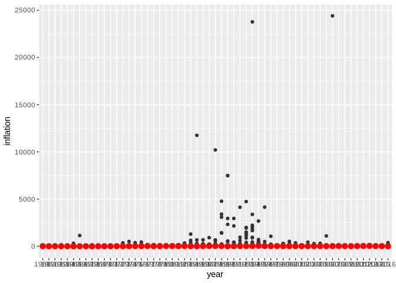

```r
# Inflation
wdidata %>% filter(`Indicator Code` == 'FP.CPI.TOTL.ZG') -> inflation
alt = data.frame()
for(i in 0:56){
    tmp = inflation %>% select(5+i, `Country Code`) %>% mutate(year = 1960+i) %>% select(inflation = 1, year, `Country Code`)
    alt = bind_rows(alt, tmp)
}
inflation = alt %>% na.omit()
inflation$year = as.factor(inflation$year)
ggplot(data = inflation, aes(x = year, y = inflation)) + geom_boxplot() +
    geom_point(data = inflation %>% filter(`Country Code` == 'IRN'), color='red', size = 3)
```

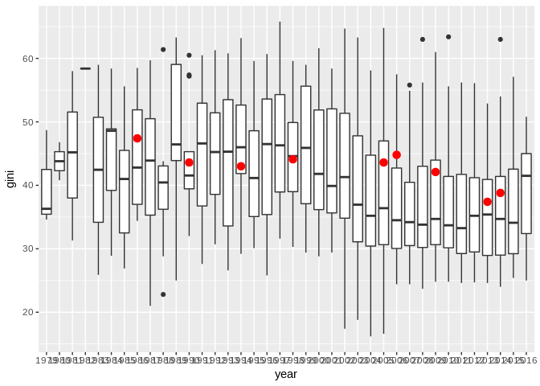

```r
# GINI index
wdidata %>% filter(`Indicator Code` == 'SI.POV.GINI') -> gini
alt = data.frame()
for(i in 0:56){
    tmp = gini %>% select(5+i, `Country Code`) %>% mutate(year = 1960+i) %>% select(gini = 1, year, `Country Code`)
    alt = bind_rows(alt, tmp)
}
gini = alt %>% na.omit()
gini$year = as.factor(gini$year)
ggplot(data = gini, aes(x = year, y = gini)) + geom_boxplot() +
    geom_point(data = gini %>% filter(`Country Code` == 'IRN'), color='red', size = 3)
```

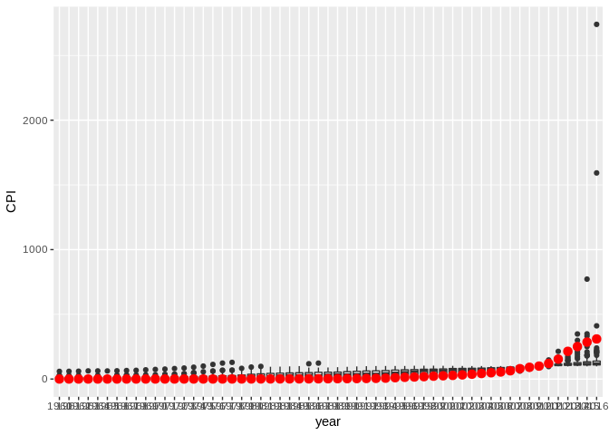

```r
# Consumer Price Index
wdidata %>% filter(`Indicator Code` == 'FP.CPI.TOTL') -> CPI
alt = data.frame()
for(i in 0:56){
    tmp = CPI %>% select(5+i, `Country Code`) %>% mutate(year = 1960+i) %>% select(CPI = 1, year, `Country Code`)
    alt = bind_rows(alt, tmp)
}
CPI = alt %>% na.omit()
CPI$year = as.factor(CPI$year)
ggplot(data = CPI, aes(x = year, y = CPI)) + geom_boxplot() +
    geom_point(data = CPI %>% filter(`Country Code` == 'IRN'), color='red', size = 3)
```

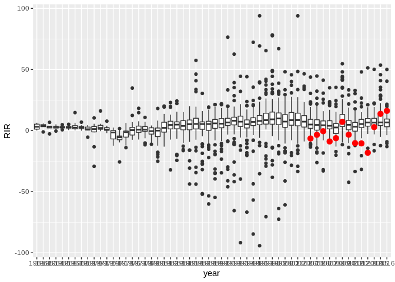

```r
# Real interest Rate
wdidata %>% filter(`Indicator Code` == 'FR.INR.RINR') -> RIR
alt = data.frame()
for(i in 0:56){
    tmp = RIR %>% select(5+i, `Country Code`) %>% mutate(year = 1960+i) %>% select(RIR = 1, year, `Country Code`)
    alt = bind_rows(alt, tmp)
}
RIR = alt %>% na.omit()
RIR$year = as.factor(RIR$year)
ggplot(data = RIR, aes(x = year, y = RIR)) + geom_boxplot() +
    geom_point(data = RIR %>% filter(`Country Code` == 'IRN'), color='red', size = 3)
```

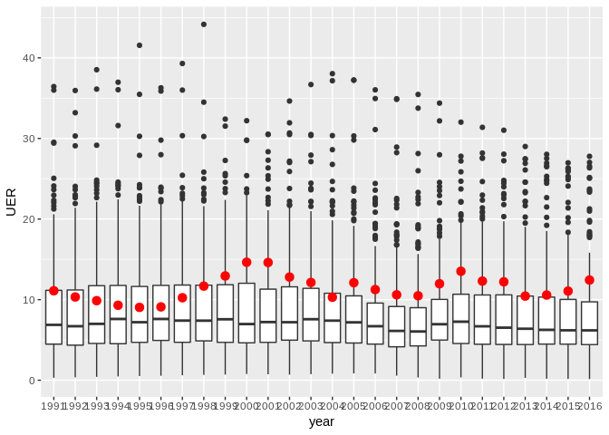

```r
# Unemployment Rate
wdidata %>% filter(`Indicator Code` == 'SL.UEM.TOTL.ZS') -> UER
alt = data.frame()
for(i in 0:56){
    tmp = UER %>% select(5+i, `Country Code`) %>% mutate(year = 1960+i) %>% select(UER = 1, year, `Country Code`)
    alt = bind_rows(alt, tmp)
}
UER = alt %>% na.omit()
UER$year = as.factor(UER$year)
ggplot(data = UER, aes(x = year, y = UER)) + geom_boxplot() +
    geom_point(data = UER %>% filter(`Country Code` == 'IRN'), color='red', size = 3)
```

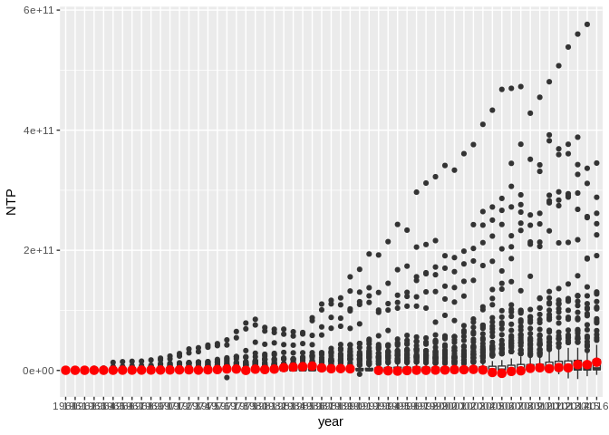

```r
# Net Tax on Products
wdidata %>% filter(`Indicator Code` == 'NY.TAX.NIND.CD') -> NTP
alt = data.frame()
for(i in 0:56){
    tmp = NTP %>% select(5+i, `Country Code`) %>% mutate(year = 1960+i) %>% select(NTP = 1, year, `Country Code`)
    alt = bind_rows(alt, tmp)
}
NTP = alt %>% na.omit()
NTP$year = as.factor(NTP$year)
ggplot(data = NTP, aes(x = year, y = NTP)) + geom_boxplot() +
    geom_point(data = NTP %>% filter(`Country Code` == 'IRN'), color='red', size = 3)
```

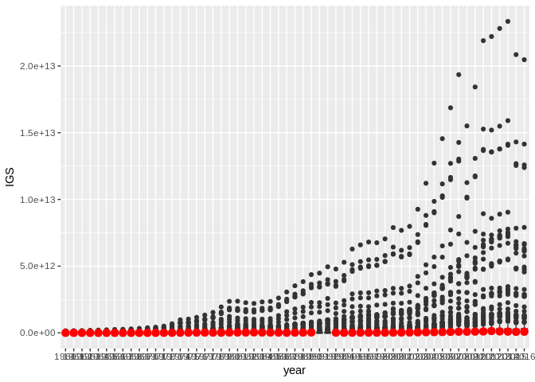

```r
# Imports of goods and services
wdidata %>% filter(`Indicator Code` == 'NE.IMP.GNFS.CD') -> IGS
alt = data.frame()
for(i in 0:56){
    tmp = IGS %>% select(5+i, `Country Code`) %>% mutate(year = 1960+i) %>% select(IGS = 1, year, `Country Code`)
    alt = bind_rows(alt, tmp)
}
IGS = alt %>% na.omit()
IGS$year = as.factor(IGS$year)
ggplot(data = IGS, aes(x = year, y = IGS)) + geom_boxplot() +
    geom_point(data = IGS %>% filter(`Country Code` == 'IRN'), color='red', size = 3)
```

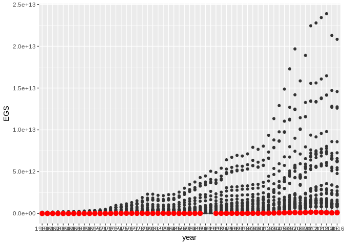

```r
# Exports of goods and services
wdidata %>% filter(`Indicator Code` == 'NE.EXP.GNFS.CD') -> EGS
alt = data.frame()
for(i in 0:56){
    tmp = EGS %>% select(5+i, `Country Code`) %>% mutate(year = 1960+i) %>% select(EGS = 1, year, `Country Code`)
    alt = bind_rows(alt, tmp)
}
EGS = alt %>% na.omit()
EGS$year = as.factor(EGS$year)
ggplot(data = EGS, aes(x = year, y = EGS)) + geom_boxplot() +
    geom_point(data = EGS %>% filter(`Country Code` == 'IRN'), color='red', size = 3)
```

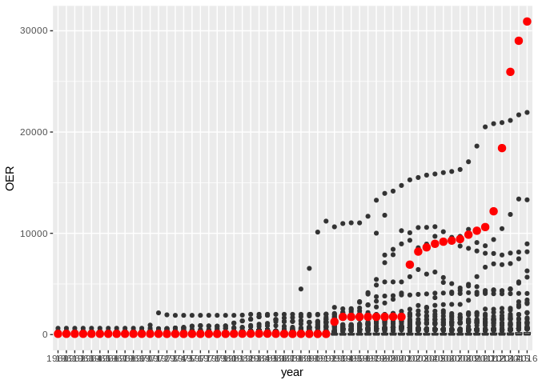

```r
# Official Exchange Rate
wdidata %>% filter(`Indicator Code` == 'PA.NUS.FCRF') -> OER
alt = data.frame()
for(i in 0:56){
    tmp = OER %>% select(5+i, `Country Code`) %>% mutate(year = 1960+i) %>% select(OER = 1, year, `Country Code`)
    alt = bind_rows(alt, tmp)
}
OER = alt %>% na.omit()
OER$year = as.factor(OER$year)
ggplot(data = OER %>% filter(`Country Code` != 'ZWE'), aes(x = year, y = OER)) + geom_boxplot() +
    geom_point(data = OER %>% filter(`Country Code` == 'IRN'), color='red', size = 3, aes(x = year, y=OER))
```

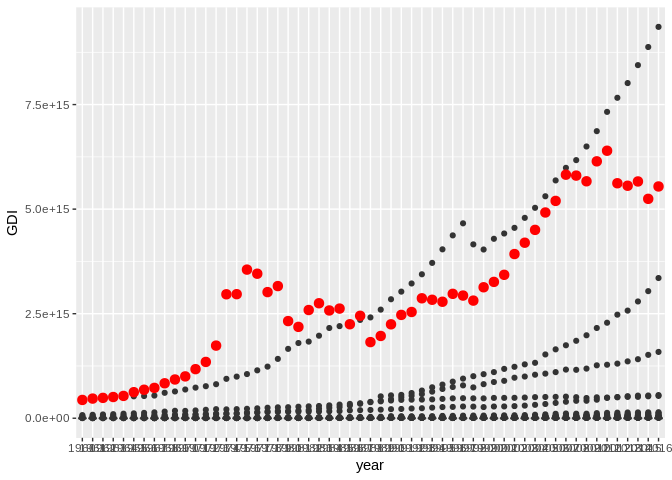

```r
# Gross Domestic Income
wdidata %>% filter(`Indicator Code` == 'NY.GDY.TOTL.KN') -> GDI
alt = data.frame()
for(i in 0:56){
    tmp = GDI %>% select(5+i, `Country Code`) %>% mutate(year = 1960+i) %>% select(GDI = 1, year, `Country Code`)
    alt = bind_rows(alt, tmp)
}
GDI = alt %>% na.omit()
GDI$year = as.factor(GDI$year)
ggplot(data = GDI, aes(x = year, y = GDI)) + geom_boxplot() +
    geom_point(data = GDI %>% filter(`Country Code` == 'IRN'), color='red', size = 3, aes(x = year, y=GDI))
```

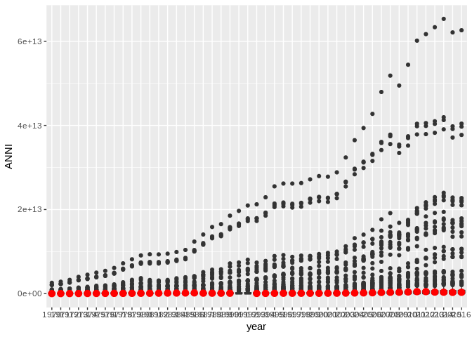

```r
# Adjusted Net National Income
wdidata %>% filter(`Indicator Code` == 'NY.ADJ.NNTY.CD') -> ANNI
alt = data.frame()
for(i in 0:56){
    tmp = ANNI %>% select(5+i, `Country Code`) %>% mutate(year = 1960+i) %>% select(ANNI = 1, year, `Country Code`)
    alt = bind_rows(alt, tmp)
}
ANNI = alt %>% na.omit()
ANNI$year = as.factor(ANNI$year)
ggplot(data = ANNI, aes(x = year, y = ANNI)) + geom_boxplot() +
    geom_point(data = ANNI %>% filter(`Country Code` == 'IRN'), color='red', size = 3, aes(x = year, y=ANNI))
```

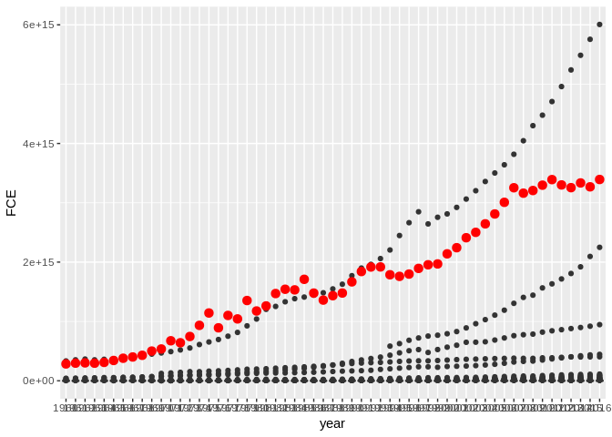

```r
# Final Consumtion Expenditure
wdidata %>% filter(`Indicator Code` == 'NE.CON.TOTL.KN') -> FCE
alt = data.frame()
for(i in 0:56){
    tmp = FCE %>% select(5+i, `Country Code`) %>% mutate(year = 1960+i) %>% select(FCE = 1, year, `Country Code`)
    alt = bind_rows(alt, tmp)
}
FCE = alt %>% na.omit()
FCE$year = as.factor(FCE$year)
ggplot(data = FCE, aes(x = year, y = FCE)) + geom_boxplot() +
    geom_point(data = FCE %>% filter(`Country Code` == 'IRN'), color='red', size = 3, aes(x = year, y=FCE))
```

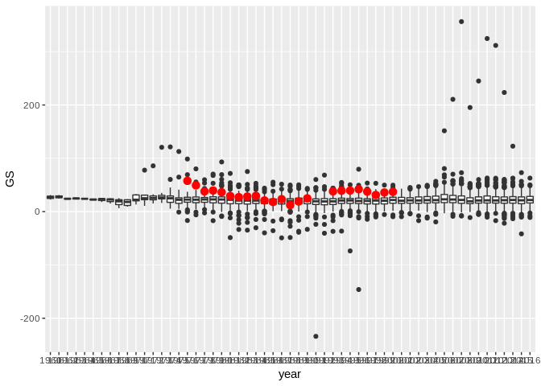

```r
# Gross Savings
wdidata %>% filter(`Indicator Code` == 'NY.GNS.ICTR.ZS') -> GS
alt = data.frame()
for(i in 0:56){
    tmp = GS %>% select(5+i, `Country Code`) %>% mutate(year = 1960+i) %>% select(GS = 1, year, `Country Code`)
    alt = bind_rows(alt, tmp)
}
GS = alt %>% na.omit()
GS$year = as.factor(GS$year)
ggplot(data = GS, aes(x = year, y = GS)) + geom_boxplot() +
    geom_point(data = GS %>% filter(`Country Code` == 'IRN'), color='red', size = 3, aes(x = year, y=GS))
```

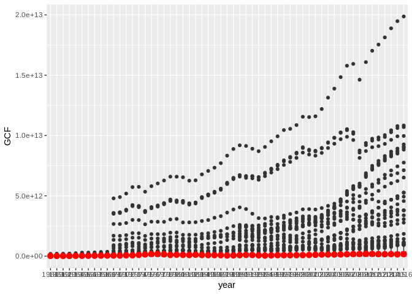

```r
# Gross Capital Formation
wdidata %>% filter(`Indicator Code` == 'NE.GDI.TOTL.KD') -> GCF
alt = data.frame()
for(i in 0:56){
    tmp = GCF %>% select(5+i, `Country Code`) %>% mutate(year = 1960+i) %>% select(GCF = 1, year, `Country Code`)
    alt = bind_rows(alt, tmp)
}
GCF = alt %>% na.omit()
GCF$year = as.factor(GCF$year)
ggplot(data = GCF, aes(x = year, y = GCF)) + geom_boxplot() +
    geom_point(data = GCF %>% filter(`Country Code` == 'IRN'), color='red', size = 3, aes(x = year, y=GCF))
```

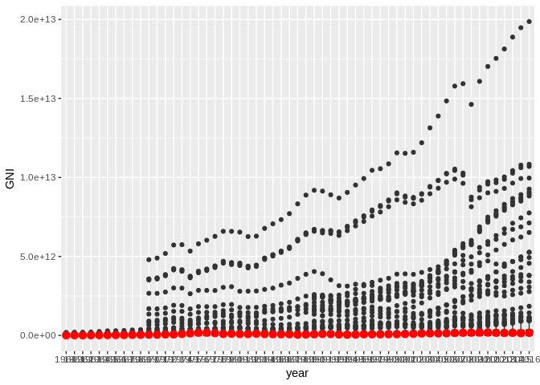

```r
# GNI
wdidata %>% filter(`Indicator Code` == 'NE.GDI.TOTL.KD') -> GNI
alt = data.frame()
for(i in 0:56){
    tmp = GNI %>% select(5+i, `Country Code`) %>% mutate(year = 1960+i) %>% select(GNI = 1, year, `Country Code`)
    alt = bind_rows(alt, tmp)
}
GNI = alt %>% na.omit()
GNI$year = as.factor(GNI$year)
ggplot(data = GNI, aes(x = year, y = GNI)) + geom_boxplot() +
    geom_point(data = GNI %>% filter(`Country Code` == 'IRN'), color='red', size = 3, aes(x = year, y=GNI))
```

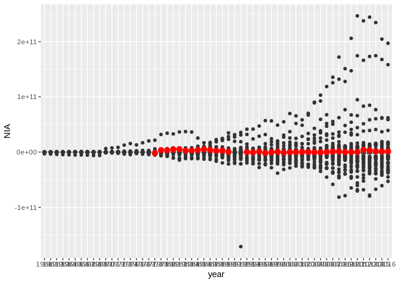

```r
# Net Incom from Abroad
wdidata %>% filter(`Indicator Code` == 'NY.GSR.NFCY.CD') -> NIA
alt = data.frame()
for(i in 0:56){
    tmp = NIA %>% select(5+i, `Country Code`) %>% mutate(year = 1960+i) %>% select(NIA = 1, year, `Country Code`)
    alt = bind_rows(alt, tmp)
}
NIA = alt %>% na.omit()
NIA$year = as.factor(NIA$year)
ggplot(data = NIA, aes(x = year, y = NIA)) + geom_boxplot() +
    geom_point(data = NIA %>% filter(`Country Code` == 'IRN'), color='red', size = 3, aes(x = year, y=NIA))
```

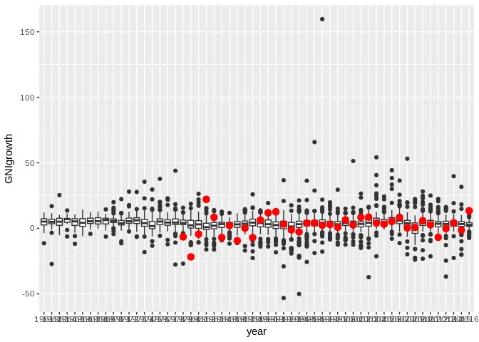

```r
# GNI growth
wdidata %>% filter(`Indicator Code` == 'NY.GNP.MKTP.KD.ZG') -> GNIgrowth
alt = data.frame()
for(i in 0:56){
    tmp = GNIgrowth %>% select(5+i, `Country Code`) %>% mutate(year = 1960+i) %>% select(GNIgrowth = 1, year, `Country Code`)
    alt = bind_rows(alt, tmp)
}
GNIgrowth = alt %>% na.omit()
GNIgrowth$year = as.factor(GNIgrowth$year)
ggplot(data = GNIgrowth, aes(x = year, y = GNIgrowth)) + geom_boxplot() +
    geom_point(data = GNIgrowth %>% filter(`Country Code` == 'IRN'), color='red', size = 3, aes(x = year, y=GNIgrowth))
```

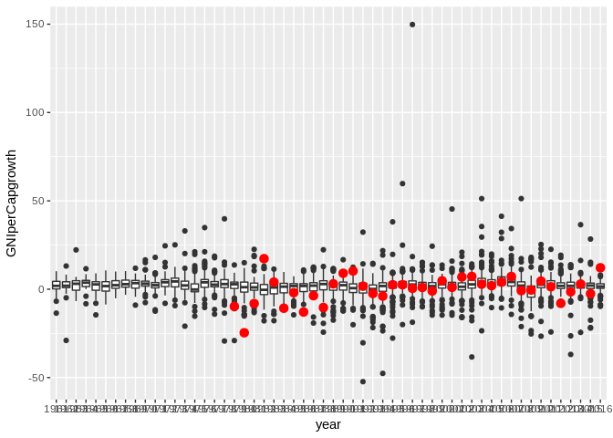

```r
# GNI per cap growth
wdidata %>% filter(`Indicator Code` == 'NY.GNP.PCAP.KD.ZG') -> GNIperCapgrowth
alt = data.frame()
for(i in 0:56){
    tmp = GNIperCapgrowth %>% select(5+i, `Country Code`) %>% mutate(year = 1960+i) %>% select(GNIperCapgrowth = 1, year, `Country Code`)
    alt = bind_rows(alt, tmp)
}
GNIperCapgrowth = alt %>% na.omit()
GNIperCapgrowth$year = as.factor(GNIperCapgrowth$year)
ggplot(data = GNIperCapgrowth, aes(x = year, y = GNIperCapgrowth)) + geom_boxplot() +
    geom_point(data = GNIperCapgrowth %>% filter(`Country Code` == 'IRN'), color='red', size = 3, aes(x = year, y=GNIperCapgrowth))
```

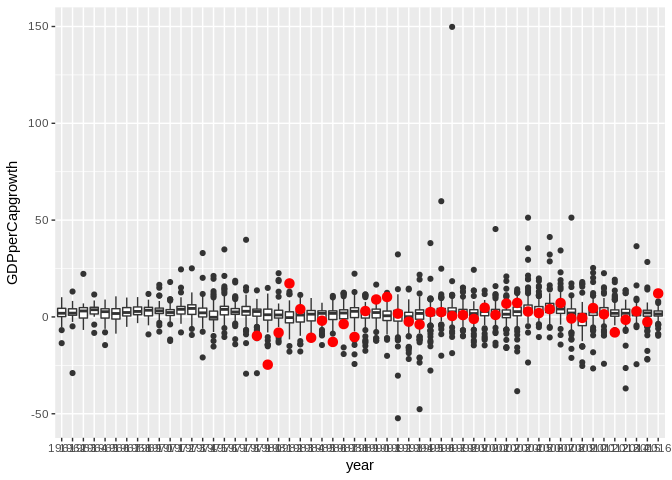

```r
# GDP per cap Growth
wdidata %>% filter(`Indicator Code` == 'NY.GNP.PCAP.KD.ZG') -> GDPperCapgrowth
alt = data.frame()
for(i in 0:56){
    tmp = GDPperCapgrowth %>% select(5+i, `Country Code`) %>% mutate(year = 1960+i) %>% select(GDPperCapgrowth = 1, year, `Country Code`)
    alt = bind_rows(alt, tmp)
}
GDPperCapgrowth = alt %>% na.omit()
GDPperCapgrowth$year = as.factor(GDPperCapgrowth$year)
ggplot(data = GDPperCapgrowth, aes(x = year, y = GDPperCapgrowth)) + geom_boxplot() +
    geom_point(data = GDPperCapgrowth %>% filter(`Country Code` == 'IRN'), color='red', size = 3, aes(x = year, y=GDPperCapgrowth))
```

۶. در قسمت قبل با استفاده از روش خوشه بندی k-means داده ها را به سه دسته تقسیم کنید. ایران در کدام دسته می گنجد؟ (پیش از خوشه بندی طبیعتا داده را باید پاکسازی و استاندارد سازی نمایید.)

```r
data = full_join(gdpGrow, inflation)
data = full_join(data, gini)
data = full_join(data, CPI)
data = full_join(data, RIR)
data = full_join(data, UER)
data = full_join(data, NTP)
data = full_join(data, IGS)
data = full_join(data, EGS)
data = full_join(data, OER)
data = full_join(data, GDI)
data = full_join(data, ANNI)
data = full_join(data, FCE)
data = full_join(data, GS)
data = full_join(data, GCF)
data = full_join(data, GNI)
data = full_join(data, NIA)
data = full_join(data, GNIgrowth)
data = full_join(data, GNIperCapgrowth)
data = full_join(data, GDPperCapgrowth)
data %>% group_by(`Country Code`) %>% summarise(gdpGrowth = mean(gdpGrowth, na.rm = T),
                                                inflation = mean(inflation, na.rm = T),
                                                gini = mean(gini, na.rm = T),
                                                CPI = mean(CPI, na.rm = T),
                                                RIR = mean(RIR, na.rm = T),
                                                UER = mean(UER, na.rm = T),
                                                NTP = mean(NTP, na.rm = T),
                                                IGS = mean(IGS, na.rm = T),
                                                EGS = mean(EGS, na.rm = T),
                                                OER = mean(OER, na.rm = T),
                                                GDI = mean(GDI, na.rm = T),
                                                ANNI = mean(ANNI, na.rm = T),
                                                FCE = mean(FCE, na.rm = T),
                                                GS = mean(GS, na.rm = T),
                                                GCF = mean(GCF, na.rm = T),
                                                GNI = mean(GNI, na.rm = T),
                                                NIA = mean(NIA, na.rm = T),
                                                GNIgrowth = mean(GNIgrowth, na.rm = T),
                                                GNIperCapgrowth = mean(GNIperCapgrowth, na.rm = T),
                                                GDPperCapgrowth = mean(GDPperCapgrowth, na.rm = T)) -> data
data = data[complete.cases(data),]
main = data %>% select(gdpGrowth, inflation, gini, CPI, RIR, UER, NTP, IGS, EGS, OER, GDI, ANNI, FCE,
                       GS, GCF, GNI, NIA, GNIgrowth, GNIperCapgrowth, GDPperCapgrowth)
for(i in 1:20){
    main[,i] = main[,i] / max(abs(main[,i]))
}
cluster = kmeans(as.matrix(main), 3)
data$cluster = cluster$cluster
print(data %>% filter(`Country Code` == 'IRN') %>% select(`Country Code`, cluster))
```

```
## # A tibble: 1 x 2
##   `Country Code` cluster
##   <chr>            <int>
## 1 IRN                  3
```

۷. به وسیله تحلیل مولفه اصلی بعد داده رو به دو کاهش دهید سپس خوشه های به دست آمده در قسمت قبل را بر روی آن نمایش دهید. آیا عملکرد روش خوشه بندی شما مطلوب بوده است؟

```r
pca = prcomp(main, center = T)
featVec = pca$rotation[,1:2]
compData = as.data.frame(t(t(featVec) %*% t(main)))
compData$cluster = data$cluster
hchart(compData, hcaes(x = PC1, y=PC2, color = cluster), type='point')
```

[interactive chart not shown]

۸. با استفاده از داده روشی برای پیش بینی رشد اقتصادی ایران در سال آینده ارائه دهید.

We can use these 20 factors gathered along with their values in previous years to train a regression model for growth rate prediction.

۱۱. سه یافته جالب از داده ها استخراج کنید.

In figure below we can see the countries with highest life expectancy:

```r
lifeExp$average = rowMeans(lifeExp %>% select(5:61), na.rm = T)
lifeExp %>% arrange(desc(average)) %>% head(10) %>% select(`Country Name`, average) -> lifeExpRep
hchart(lifeExpRep, hcaes(x= `Country Name`, y = average), type = 'bar') %>%
    hc_yAxis(title = list(text = 'Life Expectancy')) %>%
    hc_xAxis(title = list(text = 'Country Name'))
```

[interactive chart not shown]

In figure below we can see the countries with lowest unemployment rate:

```r
UER = wdidata %>% filter(`Indicator Code` == 'SL.UEM.TOTL.ZS')
UER$average = rowMeans(UER %>% select(5:61), na.rm = T)
UER %>% arrange(average) %>% head(10) %>% select(`Country Name`, average) -> UERrep
hchart(UERrep, hcaes(x= `Country Name`, y = average), type = 'bar') %>%
    hc_yAxis(title = list(text = 'Unemployment Rate')) %>%
    hc_xAxis(title = list(text = 'Country Name'))
```

[interactive chart not shown]

Does countries with higher GDP per capita has lower unemployment rate?

```r
wdidata %>% filter(`Indicator Code` == "NY.GDP.PCAP.CD") -> GDPperCapita
alt = data.frame()
for(i in 0:56){
    tmp = GDPperCapita %>% select(5+i, `Country Name`) %>% mutate(year = 1960+i) %>% select(GDPperCapita = 1, year, `Country Name`)
    alt = bind_rows(alt, tmp)
}
GDPperCapita = alt %>% na.omit()
GDPperCapita$year = as.factor(GDPperCapita$year)
wdidata %>% filter(`Indicator Code` == 'SL.UEM.TOTL.ZS') -> UER
alt = data.frame()
for(i in 0:56){
    tmp = UER %>% select(5+i, `Country Name`) %>% mutate(year = 1960+i) %>% select(UER = 1, year, `Country Name`)
    alt = bind_rows(alt, tmp)
}
UER = alt %>% na.omit()
UER$year = as.factor(UER$year)
data = full_join(UER, GDPperCapita) %>% na.omit()
```

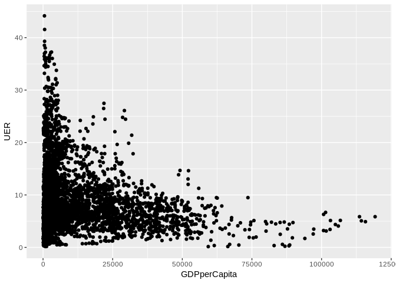

```r
data %>% select(`Country Name`, year, GDPperCapita, UER) -> data
ggplot(data = data, aes(x = GDPperCapita, y = UER)) + geom_point()
```

```r
cor.test(data$GDPperCapita, data$UER)
```

```
##
##  Pearson's product-moment correlation
##
## data:  data$GDPperCapita and data$UER
## t = -8.5608, df = 5784, p-value < 2.2e-16
## alternative hypothesis: true correlation is not equal to 0
## 95 percent confidence interval:
##  -0.13723038 -0.08633942
## sample estimates:
##        cor
## -0.1118582
```

We can see that with increase in GDP per capita, unemployment rate decreases in general. We can see a correlation of -0.11 in result of correlation test.